# Manifestation of the climate change in Texas from 1950 until today

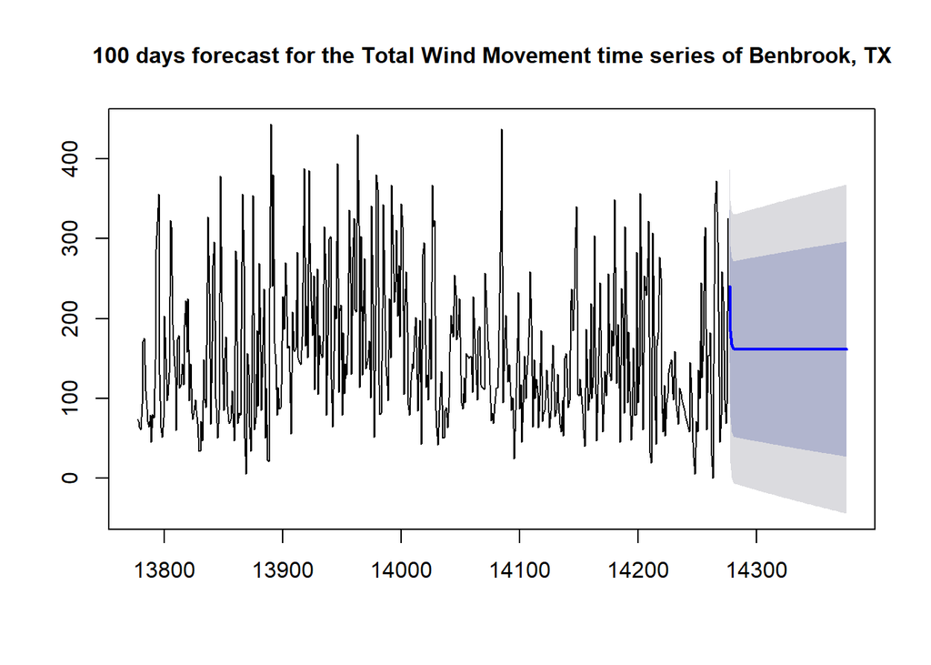

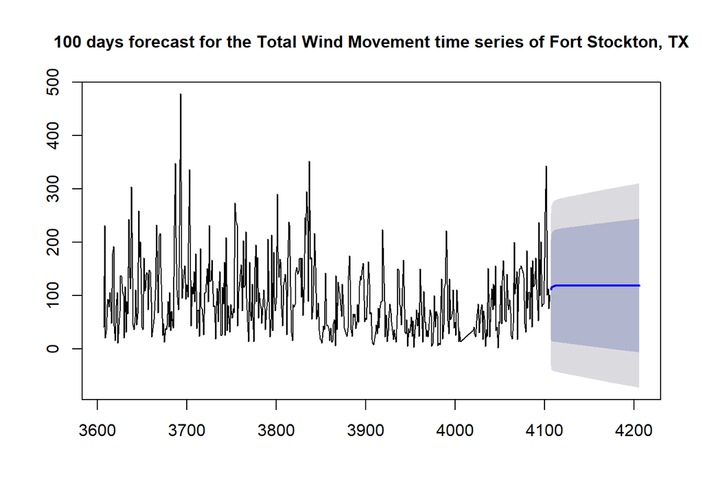

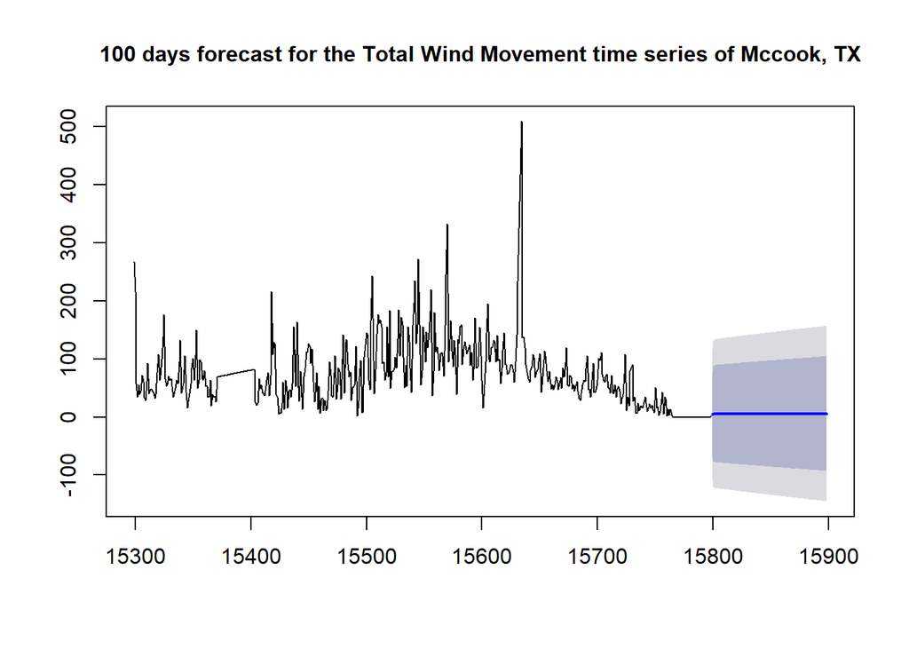

#### Averaged monthly data

For the kriging interpolation the averaged daily average wind speeds are used. Since these measurements are only observed since 1980 the kriging includes only the years 1985, 1995, 2005 and 2015. The kriging results for January show no clear trend at first glance. The visualizations are a bit confusing since the results for 2015 and 2005 have a very high maximum wind speed class which only applies for very small regions in the west of Texas.

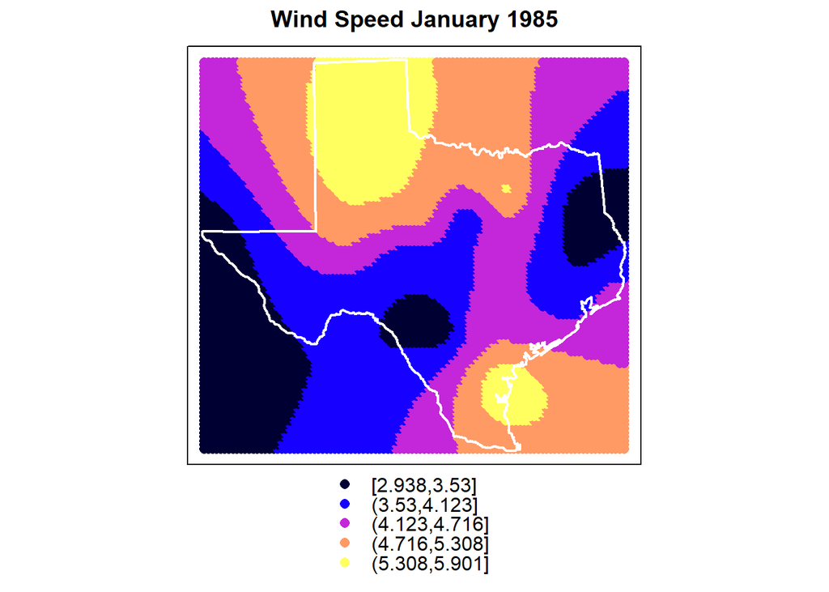

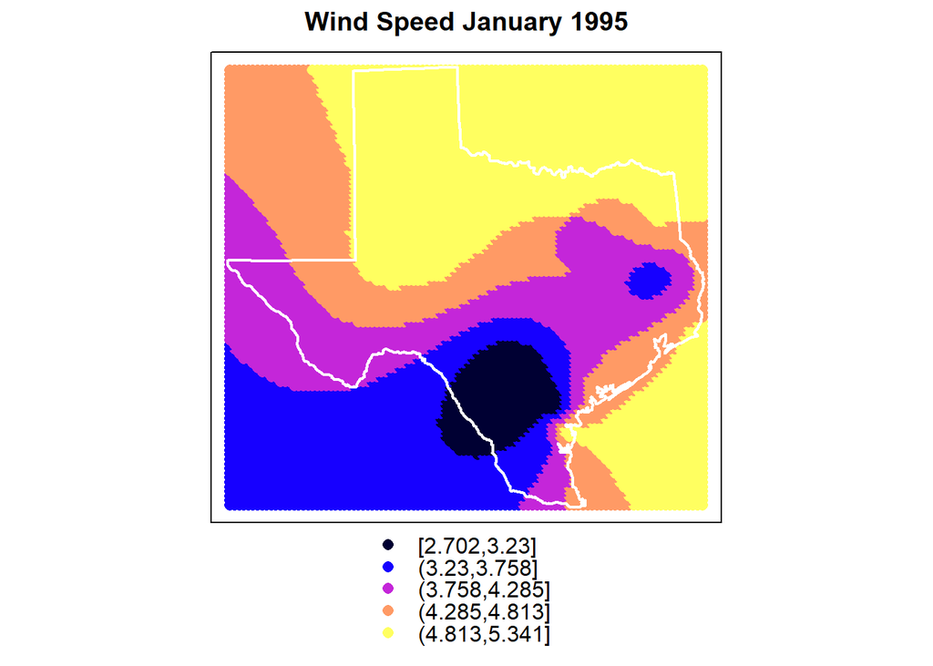

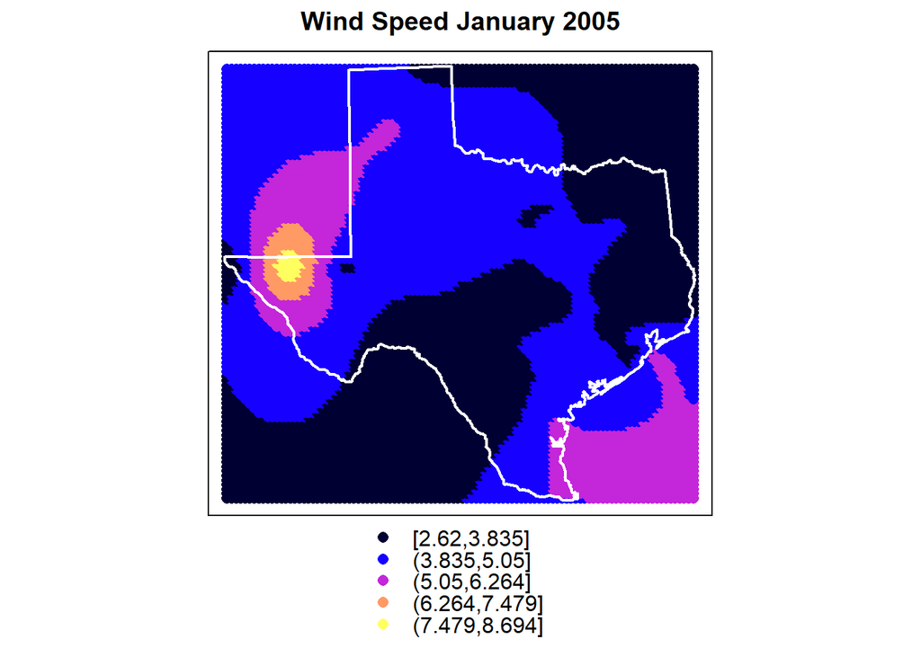

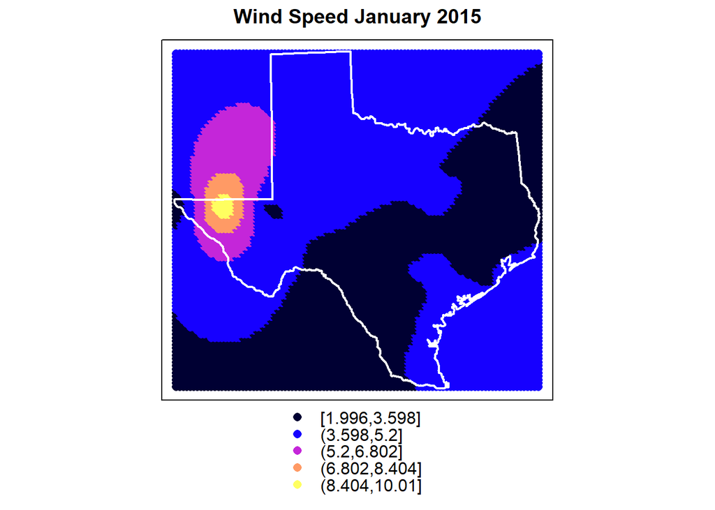

By comparing the statistical values, we see a distinct decreasing trend in wind speed. The average wind speed of 1985 is about 0.7 m/h faster compared to the average wind speed of 2015. Only the variability gets stronger which is represented by the highest standard deviation in 2015. We have on average a slower wind speed but more days with an unusual high wind speed.

Statistics of averaged Wind Speed values in January

|  | Mean | Min | Max | Std. Dev. |
| --- | --- | --- | --- | --- |
| 1985 | 4.4246800 | 2.9355 | 5.9452 | 0.9422405 |
| 1995 | 4.3287565 | 2.7000 | 5.4194 | 0.7896381 |
| 2005 | 4.0709700 | 2.5968 | 8.7935 | 0.9119074 |
| 2015 | 3.7460735 | 1.9700 | 10.1400 | 1.0708173 |
| Difference 2015 - 1985 | -0.6786065 | -0.9655 | 4.1948 | 0.1285768 |

In August we have the same confusing visualizations of 2015 and 2005 like in January since some high measurements disturb the interpolation. By this it is again hard to recognize a trend. Like in January the highest wind speeds appear in the west and in the north of Texas. As expected the wind speeds in august are much slower compared to January.

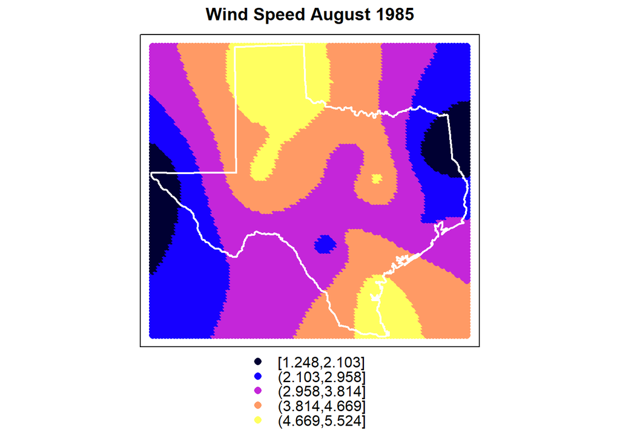

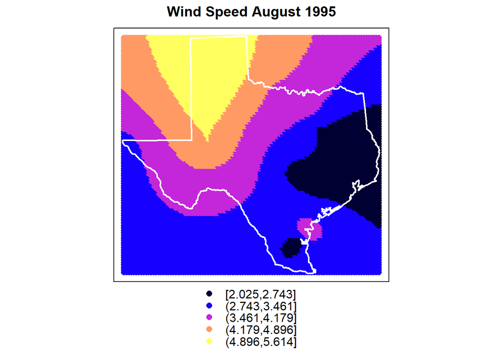

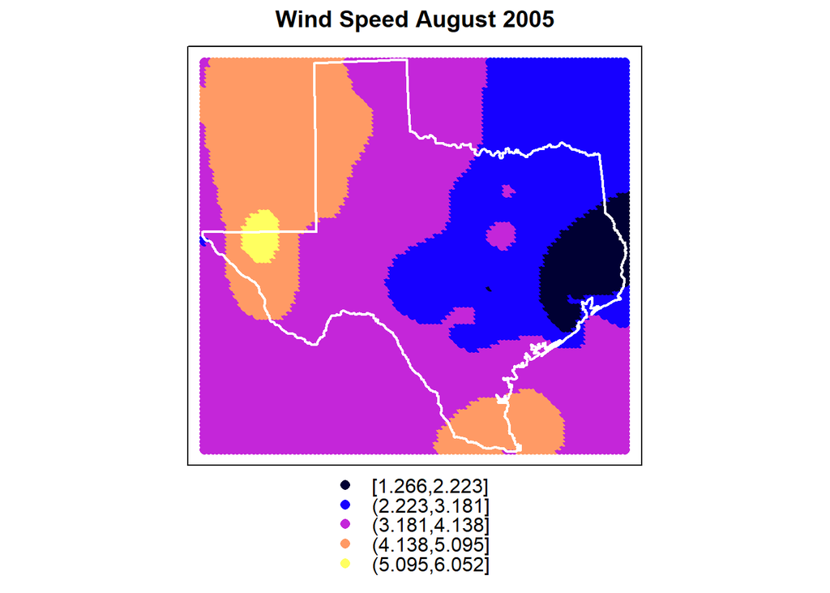

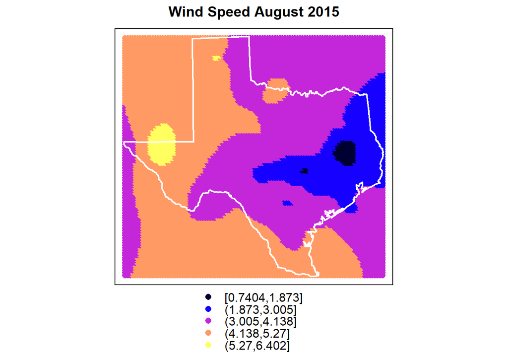

Unlike in January the comparison of the basic statistical values shows no clear trend. If we would leave out 2015 there is again a decreasing trend. 2015 the data has the largest variability regarding the difference between the minimal and maximal value. Different from before the standard deviation is not highest in 2015.

Statistics of averaged Wind Speed values in August

|  | Mean | Min | Max | Std. Dev. |
| --- | --- | --- | --- | --- |
| 1985 | 3.7595200 | 1.2065 | 5.5484 | 1.2193723 |
| 1995 | 3.4626500 | 2.0129 | 5.6258 | 1.0092336 |
| 2005 | 3.1730700 | 1.1806 | 6.1000 | 0.9342598 |
| 2015 | 3.4751397 | 0.6161 | 6.4452 | 1.0244006 |
| Difference 2015 - 1985 | -0.2843803 | -0.5904 | 0.8968 | -0.1949717 |

Summarized the wind speed seems to decrease with the climate change. Since there was a clear decreasing trend in the data sets for January and the differences in the data sets for August were only very small, this indicates an overall decreasing trend.

#### Comparison coast interior

For the first time the comparison of the slope of the time series trends shows no difference between coast and interior. This result must be considered carefully since the time series have not the same temporal extent. Nevertheless, it again shows a decreasing overall trend of the wind movement.

Slope of trend of the Total Wind Movement time series on the coast and in the interior

|  | Slope of trend |
| --- | --- |
| Angleton, East (Coast) | 0.1814185 |
| Mccook, South (Coast) | -1.9768815 |
| Benbrook, North (Interior) | 0.6498487 |
| Fort Stockton, West (Interior) | -2.3169080 |
| Mean (Coast) | -0.8977315 |
| Mean(Interior) | -0.8335297 |

## Discussion

The results of the analysis show that there is a remarkable climate change in Texas over the last 70 years. The temperature has risen by about 1 degree in August and is predicted to further increase. The precipitation shows a small increase by about 2 mm in January and is also predicted to further increase. The evaporation is decreasing even if the results are not completely distinct. The wind speed and total wind movement are also decreasing. There are differences in the magnitude of the climate change at the coast and in the interior. At the coast the increase of temperature is stronger as well as the decrease of evaporation while the increase of precipitation is stronger in the interior. The decrease of wind speed and wind movement shows no differences between coast and interior. Since most times the maximum values were most high in 2015 this could indicate more extreme climate conditions which could be a starting point for further research. Unfortunately, the evaporation and total wind movement time series do not cover the full temporal extent from 1950 until today but sometimes only ten years of data. This could influence the results since they were analysed in the same way as the other time series. With a more complete data set the results would be more meaningful. According to that it would be better to take more than four stations into account to get more credible results. The same applies for the kriging interpolation. With more data from different months or also additional years the results could be different and would be more meaningful. Since the used data already has a size of about 100 megabyte it would have been too computationally intensive to use more. The chosen data seemed to be the best fitting according to the research question.

## Conclusion

There is a remarkable climate change in Texas regarding the climate elements temperature, precipitation, evaporation and wind speed. By this the work provides an additional evidence of the climate change and adds to the multitude of research in this field. Further research should use more and different data for this analysis to prove these results and create more meaningful outcomes. Furthermore, other methods for the analysis could be used like dynamic time warping for example which provides algorithms to compare time series (Dynamic Time Warp Project, 2018).

## References

DallasNews, 2007. “Texas No. 1 producer of greenhouse gases”. Retrieved March 13, 2018 from: https://web.archive.org/web/20080919052620/http://www.dallasnews.com/sharedcontent/dws/news/texassouthwest/stories/060307dnnatemissions.3c1df3a.html

Dynamic Time Warp Project, 2018. “Dynamic Time Warp project”. Retrieved March 15, 2018 from: http://dtw.r-forge.r-project.org/

IPCC, 2018. “Intergovernmental Panel On Climate Change”. Retrieved March 13, 2018 from: http://www.ipcc.ch/

IPCC Working Group 1, 2007. “Climate Change 2007: The Physical Science Basis”. Contribution of Working Group I to the Fourth Assessment Report of the Intergovernmental Panel on Climate Change

IPCC Working Group 2, 2007. “Climate Change 2007: Impacts, Adaptation and Vulnerability”. Working Group II Contribution to the Intergovernmental Panel on Climate Change Fourth Assessment Report

Jouzel, J. et al. 2007. “Orbital and Millennial Antarctic Climate Variability over the Past 800,000 Years”. Science 317 (5839), 793-796. DOI: 10.1126/science.1141038

Keeling, C. D., 1960. “The concentration and isotopic abundances of carbon dioxide in the atmosphere”. Tellus Volume 12, Number 2

NOAA, 2018. “Climate Data Online Search”. Retrieved March 13, 2018 from: https://www.ncdc.noaa.gov/cdo-web/search

Roderick, M. L. and Farquhar, G. D., 2002. “The Cause of Decreased Pan Evaporation over the Past 50 Years”. Science 298 (5597), 1410-1411. DOI: 10.1126/science.1075390-a

Schmandt, J., North, G. R. and Clarkson, J., 2011. “The impact of global warming on Texas”. 2nd Edition. Austin, TX. University of Texas Press

Texas Almanac, 2018. “Texas State Historical Association, Facts”. Retrieved March 13, 2018 from: http://texasalmanac.com/topics/facts-profile